# 贝叶斯优化理解

```python
import numpy as np
import matplotlib.pyplot as plt
from sklearn.gaussian_process import GaussianProcessRegressor
from sklearn.gaussian_process.kernels import Matern
from scipy.stats import norm
# import mean_squared_error
from sklearn.metrics import mean_squared_error

import warnings
warnings.filterwarnings("ignore")
```

```
graph LR
    A[开始] --> B[定义搜索空间]
    B --> C[选择初始采样点]
    C --> D[评估目标函数]
    D --> E[训练代理模型<br>(高斯过程回归)]
    E --> F{达到终止条件?}
    F -- 否 --> G[使用预期改进<br>选择下一个采样点]
    G --> D
    F -- 是 --> H[结束，返回最佳观测]
```

```python
# Simulated gold mining example:
# We will simulate a gold distribution along a line (1D space)
np.random.seed(42)  # for reproducibility

# This is our black-box function we are trying to optimize.
def true_gold_distribution(x):
    """Simulated true gold distribution."""
    return np.sin(3*x) + np.cos(5*x) + np.random.normal(0, 0.2, size=x.shape)

# Define the Gaussian Process model
kernel = Matern(nu=2.5)
# 在高斯过程（GP）模型中，核（kernel）是一种函数，用于衡量输入空间中两点之间的相似度。
# 不同的核函数会导致GP有不同的平滑度和波动性。
# Matérn核是一种常用的核函数，它是一类可以通过参数调整其平滑性的核。
# nu=2.5 参数控制了核的平滑程度，不同的 nu 值会导致模型具有不同的平滑性质。
gp = GaussianProcessRegressor(kernel=kernel, n_restarts_optimizer=9)
# 这是高斯过程回归（Gaussian Process Regression, GPR）模型的实例。在贝叶斯优化中，它被用作代理模型来近似未知的目标函数。
# gp 不是一个黑盒函数，而是一个通过已知数据点训练出来的模型，用来预测任意位置的函数值及其不确定性（预测的标准差）。

# Initial random samples
initial_samples = np.random.uniform(0, 2, 5).reshape(-1, 1)
initial_observations = true_gold_distribution(initial_samples)

# Update the model with initial samples
gp.fit(initial_samples, initial_observations)

def expected_improvement(X, X_sample, Y_sample, gp, xi=0.01):
    # 这个函数计算了在每个可能的新采样点上的预期改进量。
    # 它使用 gp 模型的预测及其不确定性来估算每个点的改进潜力，然后选择具有最大预期改进值的点作为下一个采样点。
    mu, sigma = gp.predict(X, return_std=True)
    mu_sample = gp.predict(X_sample)
    mu_sample_opt = np.max(mu_sample)

    with np.errstate(divide='warn'):
        imp = mu - mu_sample_opt - xi
        Z = imp / sigma
        ei = imp * norm.cdf(Z) + sigma * norm.pdf(Z)
        ei[sigma == 0.0] = 0.0  # 确保 sigma 是一维的，这样布尔索引才能正常工作

    # 这里返回的是一个数组，它包含了每个候选点的预期改进值
    # 也就是在一个x轴上的每个点的预期改进值，这个值越大，说明这个点越有可能是最优点
    # 一般来说这个数组包含了很多点，我们只需要选择其中的一个点作为下一个采样点
    # 数组的长度取决于X的长度
    return ei

def propose_location(acquisition, X_sample, Y_sample, gp):
    # 这个函数使用 expected_improvement 函数来确定下一个最佳的采样位置。
    # 它通过计算所有候选点的预期改进值，并选择具有最大值的点作为下一个采样点。
    X = np.linspace(0, 2, 400).reshape(-1, 1)
    # 这里的acquisition是一个函数，它接受X，X_sample，Y_sample，gp作为参数，并返回一个数组。在这个例子中，它是expected_improvement函数。
    acquisition_values = acquisition(X, X_sample, Y_sample, gp)

    # 这里返回的是具有最大预期改进值的点，坐标轴上是 x 值
    return X[np.argmax(acquisition_values)]
```

在每次迭代中，选定的新采样点（通过 propose_location 函数确定）会被用来评估目标函数，然后将这个新的数据点（位置和对应的函数值）加入到已有的数据集中。

然后，gp 模型会使用所有当前可用的数据点来进行重新训练（更新）。

# 拟合黄金分布

```python
# Define the space where we look for gold
X = np.linspace(0, 2, 400).reshape(-1, 1)

# Observations with noise
y_true = true_gold_distribution(X)

# Plot of the true gold distribution
plt.figure(figsize=(14, 7))
plt.plot(X, y_true, 'y--', lw=2, label='True gold distribution')
plt.scatter(X, y_true, c='y', s=50, label='True gold (simulated)', alpha=0.6)
plt.title("Simulated Gold Distribution Along a Line")
plt.xlabel("Location")
plt.ylabel("Gold quantity")
plt.legend()
plt.show()
```

[output not shown]

# 可视化 gp模型（1）

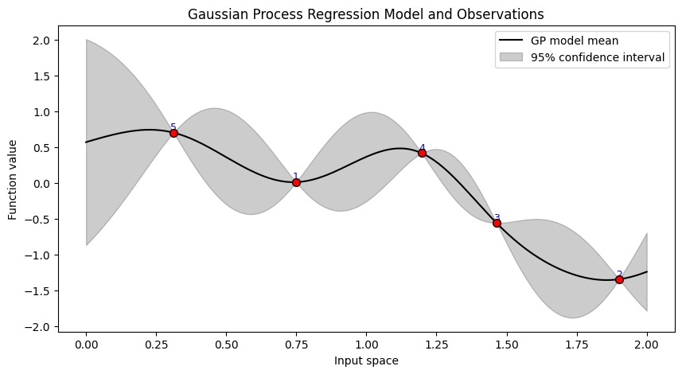

```python
# Re-initialize the samples and Gaussian Process for a fresh start
X_sample = initial_samples
Y_sample = initial_observations
gp.fit(X_sample, Y_sample)

# 定义搜索空间（即你想要预测的 X 值）
X = np.linspace(0, 2, 400).reshape(-1, 1)

# 使用 GP 模型进行预测
mu, std = gp.predict(X, return_std=True)

# 绘制预测和置信区间
plt.figure(figsize=(10, 5))
plt.plot(X, mu, 'k', lw=1.5, zorder=9, label='GP model mean')
plt.fill_between(X.ravel(), mu - 1.96 * std, mu + 1.96 * std, alpha=0.2, color='k', label='95% confidence interval')

# 绘制并标记已采样的点，包括它们的顺序
for i, (x, y) in enumerate(zip(X_sample.ravel(), Y_sample.ravel())):
    plt.scatter(x, y, c='r', s=50, zorder=10, edgecolors=(0, 0, 0))
    plt.text(x, y, str(i + 1), color='blue', fontsize=9, ha='center', va='bottom')

plt.title("Gaussian Process Regression Model and Observations")
plt.xlabel("Input space")
plt.ylabel("Function value")
plt.legend()
plt.show()
```

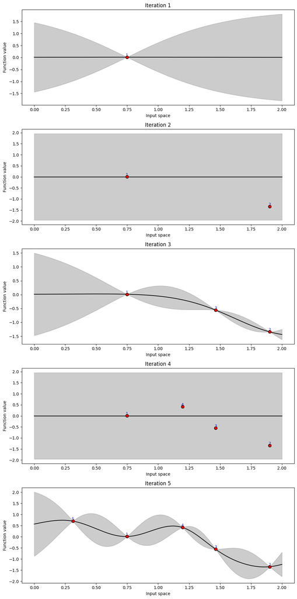

```python
# 准备绘制
fig, axs = plt.subplots(5, 1, figsize=(10, 20))

for i in range(5):
    # 每次迭代后更新高斯过程模型
    gp.fit(initial_samples[:i+1], initial_observations[:i+1])

    # 进行预测
    mu, std = gp.predict(X, return_std=True)

    # 绘制模型预测和置信区间
    axs[i].plot(X, mu, 'k', lw=1.5, zorder=9)
    axs[i].fill_between(X.ravel(), mu - 1.96 * std, mu + 1.96 * std, alpha=0.2, color='k')

    # 绘制和标记已采样点
    for j, (x, y) in enumerate(zip(initial_samples[:i+1], initial_observations[:i+1])):
        axs[i].scatter(x, y, c='r', s=50, zorder=10, edgecolors=(0, 0, 0))
        axs[i].text(x, y, f'{j+1}', color='blue', fontsize=9, ha='center', va='bottom')

    axs[i].set_title(f"Iteration {i+1}")
    axs[i].set_xlabel("Input space")
    axs[i].set_ylabel("Function value")

plt.tight_layout()
plt.show()
```

# 可视化 gp模型（2）

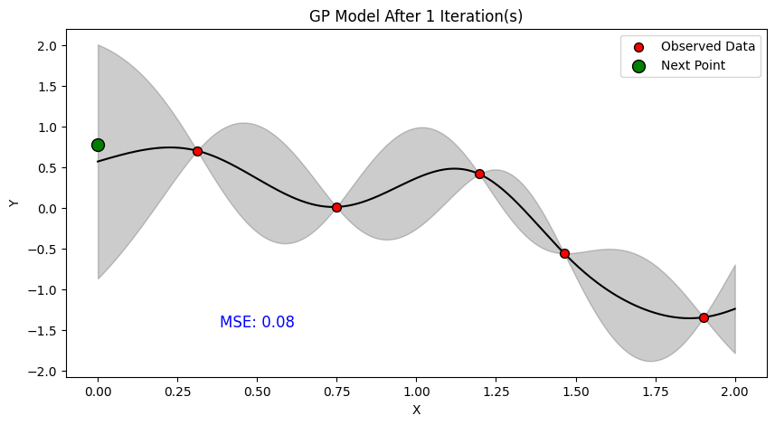

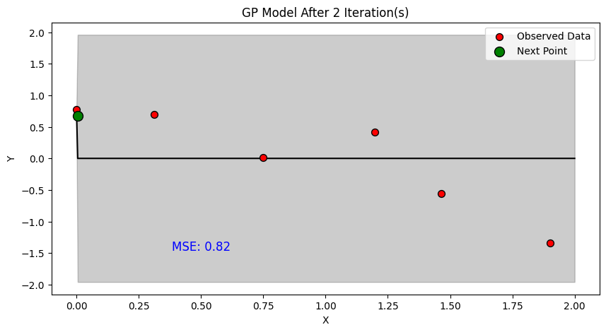

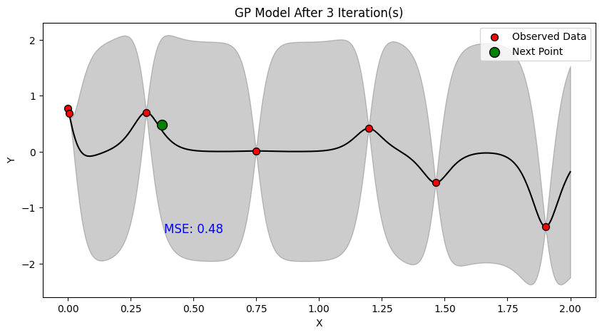

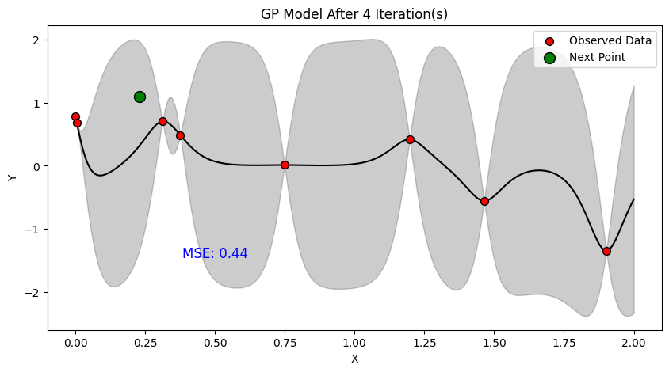

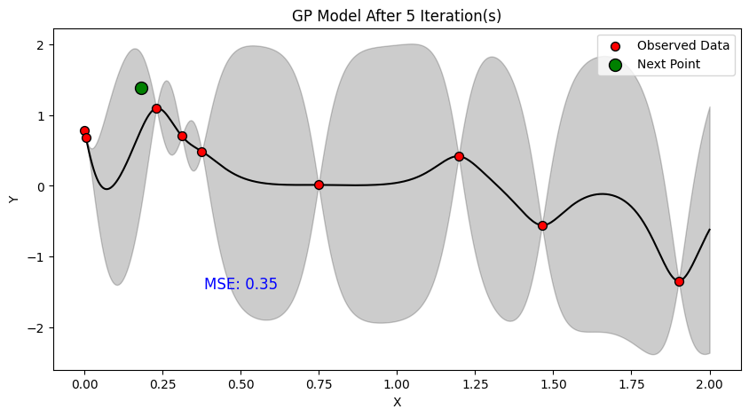

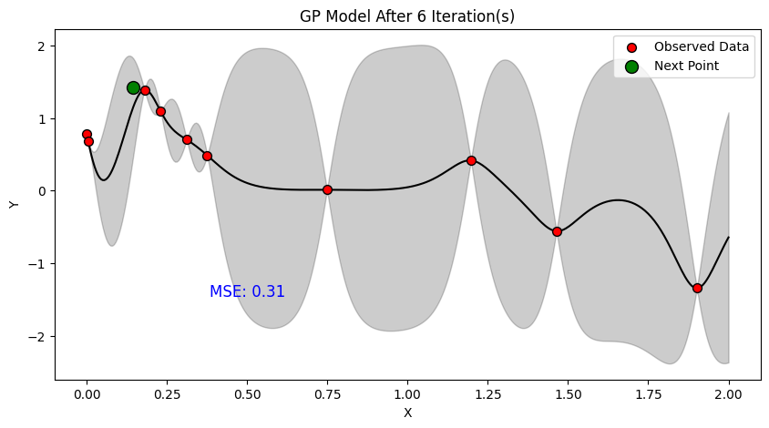

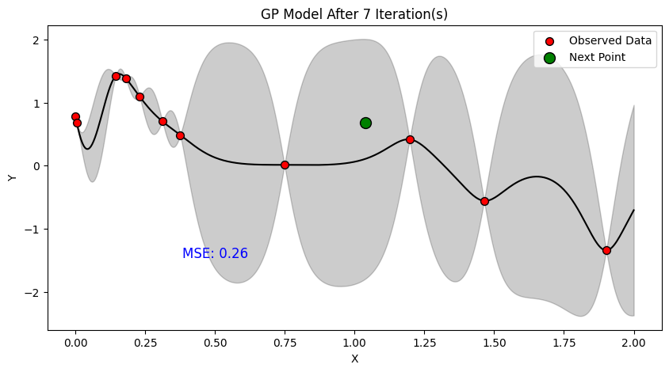

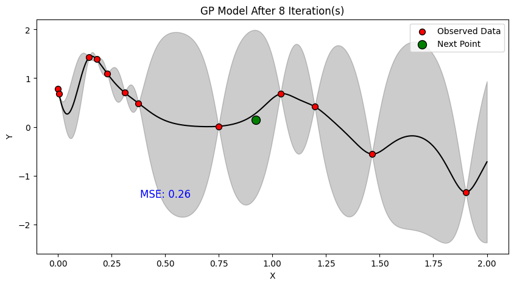

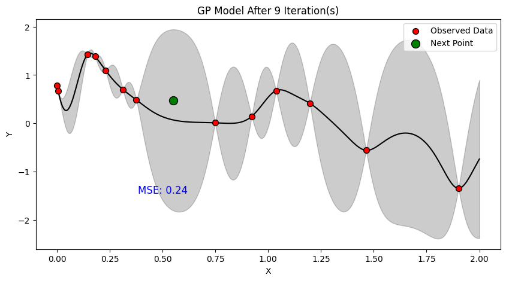

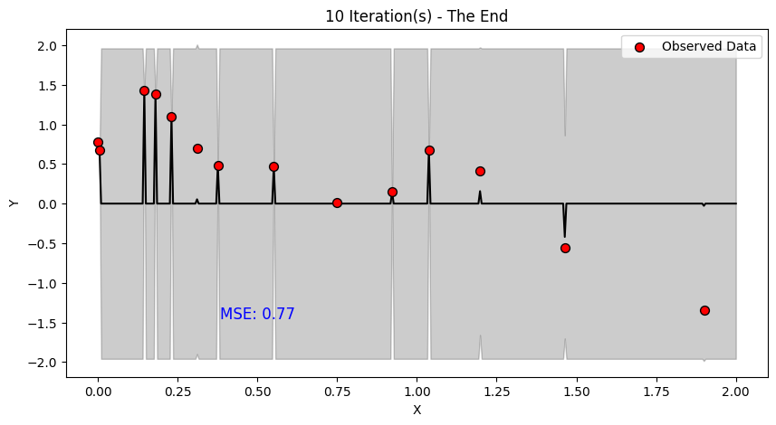

```python
# 可视化高斯过程模型的更新
X_sample = initial_samples.copy()
Y_sample = initial_observations.copy()

iteration_num = 10

for i in range(iteration_num):
    gp.fit(X_sample, Y_sample)
    X = np.linspace(0, 2, 400).reshape(-1, 1)
    mu, std = gp.predict(X, return_std=True)

    # Calculate and display the mean squared error
    mse = mean_squared_error(true_gold_distribution(X), mu)


    plt.figure(figsize=(10, 5))
    plt.plot(X, mu, 'k', lw=1.5, zorder=9)
    plt.fill_between(X.ravel(), mu - 1.96 * std, mu + 1.96 * std, alpha=0.2, color='k')
    plt.scatter(X_sample, Y_sample, c='r', s=50, zorder=10, edgecolors='k', label='Observed Data')

    # put the value of MSE in the plot, and set the position of the text, the position should be below the true gold distribution and next to the vertical line
    # Add MSE text below the true gold distribution and next to the vertical line
    plt.text(0.5, -1.5, f"MSE: {mse:.2f}", color='blue', fontsize=12, ha='center', va='bottom')

    if i < iteration_num - 1: # 最后一次迭代后不再添加新的点
        X_next = propose_location(expected_improvement, X_sample, Y_sample, gp)
        Y_next = true_gold_distribution(X_next.reshape(-1, 1))
        plt.scatter(X_next, Y_next, c='g', s=100, zorder=10, edgecolors='k', label='Next Point')

    if i < iteration_num - 1: # 最后一次迭代后不再添加新的点
        plt.title(f"GP Model After {i+1} Iteration(s)")
        plt.xlabel("X")
        plt.ylabel("Y")
        plt.legend()
    else:
        plt.title(f"{i+1} Iteration(s) - The End")
        plt.xlabel("X")
        plt.ylabel("Y")
        plt.legend()


    plt.show()

    X_sample = np.vstack((X_sample, X_next))
    Y_sample = np.vstack((Y_sample, Y_next))
```